# Lecture 8: Hypothesis testing

Economics 326 — Introduction to Econometrics II

Vadim Marmer, UBC

## Hypothesis testing

- Hypothesis testing is one of the fundamental problems in statistics.
- A hypothesis is (usually) an **assertion** about the unknown population parameters such as $\beta _{1}$ in $Y_{i}=\beta _{0}+\beta _{1}X_{i}+U_{i}.$
- Using the data, the econometrician has to determine whether an assertion is **true** or **false**.
- Example: **Phillips curve**:
  $$\text{Unemployment}_{t}=\beta _{0}+\beta _{1}\text{Inflation}_{t}+U_{t}.$$

  In this example, we are interested in testing if $\beta _{1}=0$ (no Phillips curve) against $\beta _{1}<0$ (Phillips curve).

## Null and alternative hypotheses

- Usually, we have **two competing hypotheses**, and we want to draw a conclusion, based on the data, as to which of the hypotheses is true.
- **Null hypothesis**, denoted as **$H_{0}$**: A hypothesis that is held to be true, unless the data provides **sufficient** evidence against it.
- **Alternative hypothesis**, denoted as **$H_{1}$**: A hypothesis against which the null is tested. It is held to be true if the null is found false.
- Usually, the econometrician has to carry the **“burden of proof,”** and the case that he is interested in is stated as $H_{1}$.
- The econometrician has to prove that his assertion ($H_{1}$) is true by showing that the data rejects $H_{0}$.
- The two hypotheses must be **disjoint**: it should be the case that either $H_{0}$ is true or $H_{1}$ but never both simultaneously.

## Decision rule

- The econometrician has to choose between $H_{0}$ and $H_{1}.$
- The **decision rule** that leads the econometrician to **reject or not to reject $H_{0}$** is based on a **test statistic**, which is a **function of the data** $\left\{ \left( Y_{i},X_{i}\right) :i=1,\ldots, n\right\} .$
- Usually, one rejects $H_{0}$ if the test statistic falls into a **critical region**. A critical region is constructed by taking into account the probability of making a wrong decision.

## Errors

- There are two types of errors that the econometrician can make:

  |  | Truth: $H_0$ | Truth: $H_1$ |
  | --- | --- | --- |
  | Decision: $H_0$ | $\checkmark$ | Type II error |
  | Decision: $H_1$ | Type I error | $\checkmark$ |

- **Type I error** is the error of rejecting $H_{0}$ when $H_{0}$ is true.
- The probability of Type I error is denoted by $\alpha$ and called **significance level** or **size** of a test:
  $$P\left( \text{Type I error}\right) =P\left( \text{reject }H_{0}|H_{0}\text{ is true}\right) =\alpha .$$
- **Type II error** is the error of not rejecting $H_{0}$ when $H_{1}$ is true.
- **Power** of a test:
  $$1-P\left( \text{Type II error}\right) =1-P\left( \text{Do not reject }H_{0}|H_{0}\text{ is false}\right) .$$

## Errors

- The decision rule depends on a **test statistic** $T.$
- The real line is split into two regions: **acceptance region** and **rejection region** (critical region).
- When $T$ is in the acceptance region, we do not reject $H_{0}$ (and risk making a Type II error).
- When $T$ is in the rejection (critical) region, we reject $H_{0}$ (and risk making a Type I error).
- Unfortunately, the probabilities of Type I and II errors are inversely related. By decreasing the probability of Type I error $\alpha ,$ one makes the critical region smaller, which increases the probability of the Type II error. Thus, it is impossible to make both errors arbitrarily small.
- By convention, $\alpha$ is chosen to be a small number, for example, $\alpha =0.01,0.05,$ or $0.10.$ (This is in agreement with the econometrician carrying the burden of proof).

## Steps

- The following are the steps of the hypothesis testing:
  1. Specify $H_{0}$ and $H_{1}.$
  2. Choose the significance level $\alpha .$
  3. Define a decision rule (critical region).
  4. Perform the test using the data: given the data compute the test statistic and see if it falls into the critical region.
- The decision depends on the significance level $\alpha$: larger values of $\alpha$ correspond to bigger critical regions (probability of Type I error is larger).
- It is **easier** to reject the null for larger values of $\alpha$.
- **$p$-value**: Given the data, the **smallest** significance level at which the null can be rejected.

## Assumptions

- Recall: under the **Normal Classical Linear Regression** model and conditionally on $\mathbf{X}$:
  $$\begin{align*}
  &\hat{\beta}_{1}\sim N\left( \beta _{1},\mathrm{Var}\left(\hat{\beta}_{1} \mid \mathbf{X}\right) \right), \\
  &\mathrm{Var}\left(\hat{\beta}_{1} \mid \mathbf{X}\right) =\frac{\sigma ^{2}}{\sum_{i=1}^{n}\left( X_{i}-\bar{X}\right) ^{2}}.
  \end{align*}$$

## Two-sided tests

- For $Y_{i}=\beta _{0}+\beta _{1}X_{i}+U_{i}$, consider testing
  $$H_{0}:\beta _{1}=\beta _{1,0},$$
  against
  $$H_{1}:\beta _{1}\neq \beta _{1,0}.$$
- $\beta _{1}$ is the true **unknown** value of the slope parameter.
- $\beta _{1,0}$ is a **known** number specified by the econometrician. (For example, $\beta _{1,0}$ is zero if you want to test $\beta _{1}=0$).
- Such a test is called **two-sided** because the alternative hypothesis $H_{1}$ does not specify in which direction $\beta _{1}$ can deviate from the asserted value $\beta _{1,0}.$

## Two-sided test ($\sigma^2$ known)

- Suppose for a moment that $\sigma ^{2}$ is known.
- Consider the following **test statistic**:
  $$\begin{align*}
  &T=\frac{\hat{\beta}_{1}-\beta _{1,0}}{\sqrt{\mathrm{Var}\left(\hat{\beta}_{1} \mid \mathbf{X}\right) }}, \\
  &\text{where } \mathrm{Var}\left(\hat{\beta}_{1} \mid \mathbf{X}\right) =\frac{\sigma ^{2}}{\sum_{i=1}^{n}\left( X_{i}-\bar{X}\right) ^{2}}.
  \end{align*}$$
- Consider the following **decision rule** (test):
  $$\text{Reject }H_{0}:\beta _{1}=\beta _{1,0}\text{ when }\left\vert T\right\vert >z_{1-\alpha /2},$$
  where $z_{1-\alpha /2}$ is the $\left( 1-\alpha /2\right)$ quantile of the standard normal distribution (**critical value**).

## Test validity and power

- We need to establish that:
  1. The test is **valid**, where the validity of a test means that it has **correct size** or $P\left( \text{Type I error}\right) =\alpha$:
     $$P\left( \left\vert T\right\vert >z_{1-\alpha /2}|\beta _{1}=\beta _{1,0}\right) =\alpha .$$
  2. The test has **power**: when $\beta _{1}\neq \beta _{1,0}$ ($H_{0}$ is false), the test rejects $H_{0}$ with probability that exceeds $\alpha$:
     $$P\left( \left\vert T\right\vert >z_{1-\alpha /2}|\beta _{1}\neq \beta _{1,0}\right) >\alpha .$$
- We want $P\left( \left\vert T\right\vert >z_{1-\alpha /2}|\beta _{1}\neq \beta _{1,0}\right)$ to be as large as possible.
- Note that $P\left( \left\vert T\right\vert >z_{1-\alpha /2}|\beta _{1}\neq \beta _{1,0}\right)$ depends on the true value $\beta _{1}.$

## Distribution of $T$ ($\sigma^2$ known)

- Write
  $$\begin{align*}
  T &=\frac{\hat{\beta}_{1}-\beta _{1,0}}{\sqrt{\mathrm{Var}\left(\hat{\beta}_{1} \mid \mathbf{X}\right) }}=\frac{\hat{\beta}_{1}-\beta _{1}+\beta _{1}-\beta _{1,0}}{\sqrt{\mathrm{Var}\left(\hat{\beta}_{1} \mid \mathbf{X}\right) }} \\
  &=\frac{\hat{\beta}_{1}-\beta _{1}}{\sqrt{\mathrm{Var}\left(\hat{\beta}_{1} \mid \mathbf{X}\right) }}+\frac{\beta _{1}-\beta _{1,0}}{\sqrt{\mathrm{Var}\left(\hat{\beta}_{1} \mid \mathbf{X}\right) }}.
  \end{align*}$$
- Under our assumptions and conditionally on $\mathbf{X}$:
  $$\begin{align*}
  &\hat{\beta}_{1}\sim N\left( \beta _{1},\mathrm{Var}\left(\hat{\beta}_{1} \mid \mathbf{X}\right) \right), \\
  &\text{or } \frac{\hat{\beta}_{1}-\beta _{1}}{\sqrt{\mathrm{Var}\left(\hat{\beta}_{1} \mid \mathbf{X}\right) }}\sim N\left( 0,1\right) .
  \end{align*}$$
- We have that conditionally on $\mathbf{X}$:
  $$T\sim N\left( \frac{\beta _{1}-\beta _{1,0}}{\sqrt{\mathrm{Var}\left(\hat{\beta}_{1} \mid \mathbf{X}\right) }},1\right) .$$

## Size of the test ($\sigma^2$ known)

- Conditionally on $\mathbf{X}$, we have that
  $$T\sim N\left( \frac{\beta _{1}-\beta _{1,0}}{\sqrt{\mathrm{Var}\left(\hat{\beta}_{1} \mid \mathbf{X}\right) }},1\right) .$$
- When $H_{0}:\beta _{1}=\beta _{1,0}$ is true, $T\overset{H_{0}}{\sim }N\left( 0,1\right)$ conditionally on $\mathbf{X}$.
- We reject $H_{0}$ when
  $$\left\vert T\right\vert >z_{1-\alpha /2}\Leftrightarrow T>z_{1-\alpha /2}\text{ or }T<-z_{1-\alpha /2}.$$
- Let $Z\sim N\left( 0,1\right) .$
  $$\begin{align*}
  P\left( \text{Reject }H_{0}|H_{0}\text{ is true}\right) &=P\left( Z>z_{1-\alpha /2}\right) +P\left( Z<-z_{1-\alpha /2}\right) \\
  &=\alpha /2+\alpha /2=\alpha
  \end{align*}$$

## Distribution of $T$ ($\sigma^2$ known)

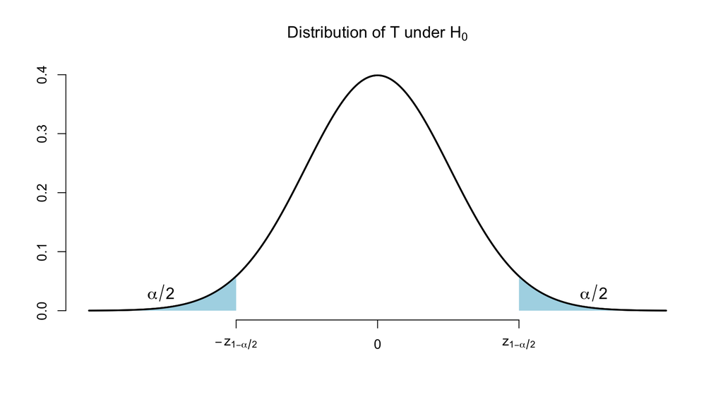

## Power ($\sigma^2$ known)

- Under $H_{1},$ $\beta _{1}-\beta _{1,0}\neq 0$ and, conditionally on $\mathbf{X}$, the distribution of $T$ is **not** centered at zero:
  $$T\sim N\left( \frac{\beta _{1}-\beta _{1,0}}{\sqrt{\mathrm{Var}\left(\hat{\beta}_{1} \mid \mathbf{X}\right) }},1\right) .$$
- When $\beta _{1}-\beta _{1,0}>0:$

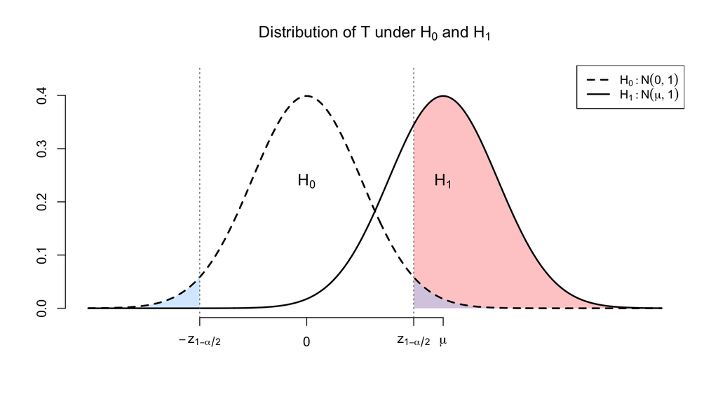

- Rejection probability exceeds $\alpha$ under $H_{1}$: power increases with the distance from $H_{0}$ ($\left\vert \beta _{1,0}-\beta _{1}\right\vert$) and decreases with $\mathrm{Var}\left(\hat{\beta}_{1} \mid \mathbf{X}\right)$.

## The two-sided $t$-test

- We are testing $H_{0}:\beta _{1}=\beta _{1,0}$ against $H_{1}:\beta _{1}\neq \beta _{1,0}.$
- When $\sigma ^{2}$ is **unknown**, we replace it with $s^{2}=\frac{1}{n-2}\sum_{i=1}^{n}\hat{U}_{i}^{2}.$
- Recall the **standard error** of $\hat{\beta}_{1}$:
  $$\mathrm{se}\left(\hat{\beta}_{1}\right) = \sqrt{\widehat{\mathrm{Var}}\left(\hat{\beta}_{1}\right)} = \sqrt{\frac{s^{2}}{\sum_{i=1}^{n}\left( X_{i}-\bar{X}\right) ^{2}}}.$$
- The **$t$-statistic**:
  $$T=\frac{\hat{\beta}_{1}-\beta _{1,0}}{\mathrm{se}\left(\hat{\beta}_{1}\right)}.$$
- We also replace the standard normal critical values $z_{1-\alpha /2}$ with the $t_{n-2}$ critical values $t_{n-2,1-\alpha /2}.$

  However, **for large $n$**, $t_{n-2,1-\alpha /2}\approx z_{1-\alpha /2}.$
- The two-sided **$t$-test**:
  $$\text{Reject }H_{0}\text{ when }\left\vert T\right\vert >t_{n-2,1-\alpha /2}.$$

## The two-sided $p$-value

- The decision to reject or not reject $H_{0}$ depends on the critical value $t_{n-2,1-\alpha /2}.$
- If $\alpha _{1}>\alpha _{2}$ then $t_{n-2,1-\alpha _{1}/2}<t_{n-2,1-\alpha _{2}/2}.$
- Thus, it is easier to reject $H_{0}$ with the significance level $\alpha _{1}$ since it corresponds to a smaller acceptance region.
- $p$-value is the **smallest** significance level $\alpha$ for which we can reject $H_{0}.$

## The two-sided $p$-value

- In order to find the $p$-value:
  1. Compute $T$.
  2. The $p$-value $= 2 \cdot P(t_{n-2} \leq -|T|).$
  3. In R: `2 * pt(-abs(T), df = n - 2)`.
- Note that for all $\alpha >p$-value,
  $$\left\vert T\right\vert =t_{n-2,1-\left( p\text{-value}\right) /2}>t_{n-2,1-\alpha /2}$$
  and we will reject $H_{0}.$
- For all $\alpha \leq p$-value,
  $$\left\vert T\right\vert =t_{n-2,1-\left( p\text{-value}\right) /2}\leq t_{n-2,1-\alpha /2}$$
  and we will not reject $H_{0}$.

## Example of $p$-value calculation

- Suppose a regression with 19 observations produced the following output:

  ```
  Coefficients:
              Estimate Std. Error t value Pr(>|t|)
  (Intercept) 10.18197    0.25094   40.58   <2e-16 ***
  x           -0.67253    0.58049   -1.16    0.263
  ```

- Here, $\hat{\beta}_{1}=-0.6725,\beta _{1,0}=0,$ and the `t value` column gives $t=-0.6725/0.5804=-1.16.$
- Thus, $\left\vert T\right\vert =1.16$ and df=17.
- The two-sided $p$-value:

  ```r
  2 * pt(-abs(-1.16), df = 17)
  ```

  ```
  [1] 0.2620816
  ```

- The $p$-value is large, so we cannot reject $H_{0}$ at conventional significance levels.

## Computing in R

- We compute critical values and $p$-values using R.
- To compute standard normal quantiles use `qnorm(τ)`, where $\tau$ is a number between 0 and 1:

  ```r
  # z critical value for a two-sided 5% test
  qnorm(1 - 0.05 / 2)
  ```

  ```
  [1] 1.959964
  ```

- For $t$ critical values use `qt(τ, df)`, where $df$ is the number of degrees of freedom and $\tau$ is the left-tail probability:

  ```r
  # t critical value for a two-sided 5% test with 62 df
  qt(1 - 0.05 / 2, df = 62)
  ```

  ```
  [1] 1.998972
  ```

## Computing in R

- To compute two-sided normal $p$-values use `2 * pnorm(-abs(T))`:

  ```r
  # Two-sided normal p-value for T = 1.96
  2 * pnorm(-abs(1.96))
  ```

  ```
  [1] 0.04999579
  ```

- To compute two-sided $t$-distribution $p$-values, use `2 * pt(-abs(T), df)`:

  ```r
  # Two-sided t p-value for T = 1.96 with 62 df
  2 * pt(-abs(1.96), df = 62)
  ```

  ```
  [1] 0.05449415
  ```

## Example

- Data: `rental` from the `wooldridge` R package. 64 US cities in 1990.
  - `rent`: average monthly rent ($)
  - `avginc`: per capita income ($)
- Model: Rent$_{i}=\beta _{0}+\beta _{1}$AvgInc$_{i}+U_{i}.$
- Regression output:

  ```r
  library(wooldridge)
  data("rental")
  rental90 <- subset(rental, y90 == 1)
  reg <- lm(rent ~ avginc, data = rental90)
  summary(reg)$coefficients
  ```

  ```
                  Estimate   Std. Error  t value     Pr(>|t|)
  (Intercept) 148.77643972 32.097874358 4.635087 1.885260e-05
  avginc        0.01158001  0.001308365 8.850748 1.340614e-12
  ```

- R reports the $t$-statistics and the $p$-value for $H_{0}:\beta_1 =0.$
- To test $H_{0}$ whether the coefficient of AvgInc is zero: $T=0.01158/0.0013084=8.85.$
- The $p$-value is extremely close to zero:

  ```r
  2 * pt(-abs(8.85), df = 62)
  ```

  ```
  [1] 1.344588e-12
  ```

  So for all reasonable significance levels $\alpha ,$ we reject $H_{0}$ that the coefficient of AvgInc is zero.
- AvgInc is a **statistically significant** regressor.

## Example (continued)

- Consider now testing $H_{0}$ that the coefficient of AvgInc is 0.009 against the alternative that it is different from 0.009.
- $T=\left( 0.01158-0.009\right) /0.0013084\approx 1.97.$

  ```r
  T_stat <- (0.01158 - 0.009) / 0.0013084
  T_stat
  ```

  ```
  [1] 1.971874
  ```

- At 5% significance level, $t_{62,0.975}\approx 1.999>T$ and we do not reject $H_{0}.$

  ```r
  qt(0.975, df = 62)
  ```

  ```
  [1] 1.998972
  ```

- At 10% significance level, $t_{62,0.95}\approx 1.67<T$ and we reject $H_{0}.$

  ```r
  qt(0.95, df = 62)
  ```

  ```
  [1] 1.669804
  ```

- The two-sided $p$-value:

  ```r
  2 * pt(-abs(T_stat), df = 62)
  ```

  ```
  [1] 0.05308963
  ```

  The $p$-value is $\approx 0.053.$
- For $\alpha \leq 0.053$ we will not reject $H_{0}$ and for $\alpha >0.053$ we will reject $H_{0}.$

## Confidence intervals and hypothesis testing

- There is a one-to-one correspondence between confidence intervals and hypothesis testing.
- We cannot reject $H_{0}:\beta _{1}=\beta _{1,0}$ against a two-sided alternative if $\left\vert T\right\vert \leq t_{n-2,1-\alpha /2}$, i.e., if and only if:
  $$\begin{align*}
  &-t_{n-2,1-\alpha /2}\leq \frac{\hat{\beta}_{1}-\beta _{1,0}}{\mathrm{se}\left(\hat{\beta}_{1}\right)}\leq t_{n-2,1-\alpha /2} \\
  &\Longleftrightarrow \\
  &\hat{\beta}_{1}-t_{n-2,1-\alpha /2} \times \mathrm{se}\left(\hat{\beta}_{1}\right) \\
  &\qquad \leq \beta _{1,0}\leq \hat{\beta}_{1}+t_{n-2,1-\alpha /2} \times \mathrm{se}\left(\hat{\beta}_{1}\right) \\
  &\Longleftrightarrow \\
  &\beta _{1,0}\in CI_{1-\alpha }.
  \end{align*}$$
- Thus, for any $\beta _{1,0}\in CI_{1-\alpha },$ we **cannot reject** $H_{0}:\beta _{1}=\beta _{1,0}$ against $H_{1}:\beta _{1}\neq \beta _{1,0}$ at significance level $\alpha .$

## Example

- The 95% confidence interval for the coefficient of AvgInc:

  ```r
  confint(reg, "avginc", level = 0.95)
  ```

  ```
               2.5 %     97.5 %
  avginc 0.008964625 0.01419539
  ```

- A significance level 5% test of $H_{0}:\beta _{1}=\beta _{1,0}$ against $H_{1}:\beta _{1}\neq \beta _{1,0}$ will not reject $H_{0}$ if $\beta _{1,0}$ is in the 95% confidence interval.

## One-sided tests

- Consider testing $H_{0}:\beta _{1}\leq \beta _{1,0}$ against $H_{1}:\beta _{1}>\beta _{1,0}.$
- It is reasonable to reject $H_{0}$ when $\hat{\beta}_{1}-\beta _{1,0}$ is large and positive or when
  $$T=\frac{\hat{\beta}_{1}-\beta _{1,0}}{\mathrm{se}\left(\hat{\beta}_{1}\right)}>c_{1-\alpha }$$
  where $c_{1-\alpha}$ is a positive constant.
- The null hypothesis $H_{0}$ is **composite**. The probability of rejection under $H_{0}$ depends on $\beta _{1}.$
- We pick the critical value $c_{1-\alpha}$ so that
  $$P\left( \frac{\hat{\beta}_{1}-\beta _{1,0}}{\mathrm{se}\left(\hat{\beta}_{1}\right)}>c_{1-\alpha }|\beta _{1}\leq \beta _{1,0}\right) \leq \alpha$$
  for all $\beta _{1}\leq \beta _{1,0}.$

## One-sided tests

- For **all** $\beta _{1}\leq \beta _{1,0},$
  $$\frac{\beta _{1}-\beta _{1,0}}{\mathrm{se}\left(\hat{\beta}_{1}\right)}\leq 0,$$
  and
  $$\begin{align*}
  &P\left( \frac{\hat{\beta}_{1}-\beta _{1,0}}{\mathrm{se}\left(\hat{\beta}_{1}\right)}>c_{1-\alpha }|\beta _{1}\leq \beta _{1,0}\right) \\
  &=P\left( \frac{\hat{\beta}_{1}-\beta _{1}}{\mathrm{se}\left(\hat{\beta}_{1}\right)}+\frac{\beta _{1}-\beta _{1,0}}{\mathrm{se}\left(\hat{\beta}_{1}\right)}>c_{1-\alpha }|\beta _{1}\leq \beta _{1,0}\right) \\
  &\leq P\left( \frac{\hat{\beta}_{1}-\beta _{1}}{\mathrm{se}\left(\hat{\beta}_{1}\right)}>c_{1-\alpha }|\beta _{1}\leq \beta _{1,0}\right) \\
  &=\alpha \text{ if }c_{1-\alpha }=t_{n-2,1-\alpha }.
  \end{align*}$$

## One-sided tests

- For size $\alpha$ test, we reject $H_{0}:\beta _{1}\leq \beta _{1,0}$ against $H_{1}:\beta _{1}>\beta _{1,0}$ when
  $$T=\frac{\hat{\beta}_{1}-\beta _{1,0}}{\mathrm{se}\left(\hat{\beta}_{1}\right)}>t_{n-2,1-\alpha },$$
  where $t_{n-2,1-\alpha}$ is the critical value corresponding to the $t$-distribution with $n-2$ degrees of freedom.
  - Note that we use $1-\alpha$ and not $1-\alpha /2$ for choosing critical values in the case of one-sided testing.
- For size $\alpha$ test, we reject $H_{0}:\beta _{1}\geq \beta _{1,0}$ against $H_{1}:\beta _{1}<\beta _{1,0}$ when
  $$T=\frac{\hat{\beta}_{1}-\beta _{1,0}}{\mathrm{se}\left(\hat{\beta}_{1}\right)}<-t_{n-2,1-\alpha }.$$

## One-sided tests

- One-sided $p$-values for $H_{0}:\beta _{1}\leq \beta _{1,0}$ against $H_{1}:\beta _{1}>\beta _{1,0}$:
  1. Compute $T$.
  2. The $p$-value $= P(t_{n-2} \geq T) = 1 - P(t_{n-2} \leq T).$
  3. In R: `1 - pt(T, df = n - 2)`.